# Sales Problem | BlackLocus

Anand Kumar Taridalu Subrahmanyam

01st July, 2016

**Summary of Observations**

This R Markdown document predicts the sales for the year, 2015 considering the historic data.

Set Working Directory and then Read the file which is located in the working Directory.

**Plot and Explore Data**

Get a general idea on dataset’s: Variables, dimensions, etc.,.

```r
head(Sales)
```

```
##                  Date Sales
## 1 2011-01-02 00:00:00    17
## 2 2011-01-03 00:00:00    13
## 3 2011-01-04 00:00:00    19
## 4 2011-01-05 00:00:00    20
## 5 2011-01-06 00:00:00    21
## 6 2011-01-07 00:00:00    16
```

```r
tail(Sales)
```

```
##                     Date Sales
## 1455 2014-12-26 00:00:00    37
## 1456 2014-12-27 00:00:00    41
## 1457 2014-12-28 00:00:00    40
## 1458 2014-12-29 00:00:00    40
## 1459 2014-12-30 00:00:00    49
## 1460 2014-12-31 00:00:00    46
```

```r
dim(Sales)
```

```
## [1] 1460    2
```

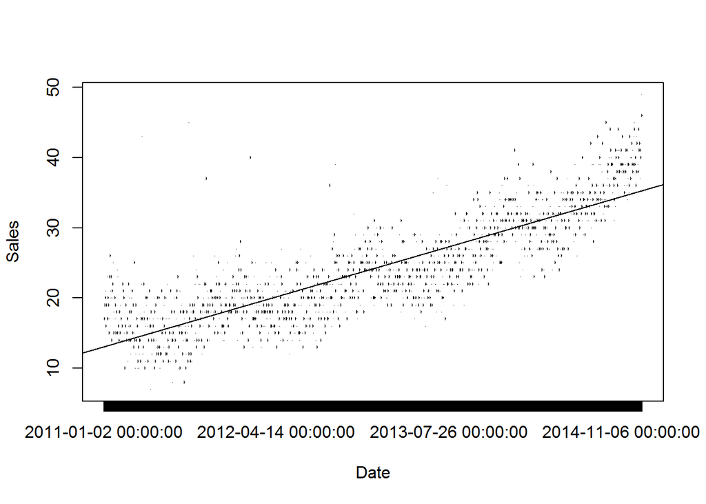

```r
# Plot of the Data

plot(Sales)
abline(reg=lm(Sales$Sales~time(Sales$Date)))
```

The Sales data given is already sorted by date, and on observing the above plot of Sales data, we can interpret the following:

##### - The trend of Sales year by year is increasing gradually, this states that the given Sales data is time dependent and is non-stationary.

##### - Hence, the Sales Data has to be made stationary before fitting any AR/MA models.

##### - The Sales data spans for four years from 2011 through 2014.

Here, we have **1460** observations and **2** variables in the Sales dataset.

**Next,**

Histograms for Sales Data

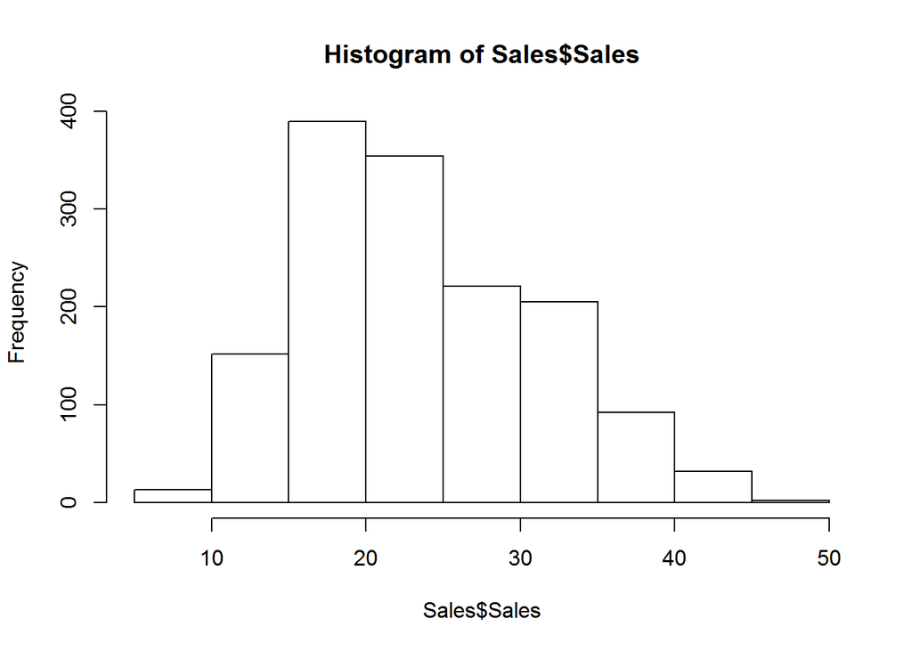

On examining the distribution of Sales, it can be seen that the range of Sales is ~[10,50] and the distribution though normal, it is skewed a bit.

**Manually finding the differencing factor for this Data, as we would need the differecing level where the data becomes stationary, before fitting ARIMA models**

1. Plot Sales Data AS-IS

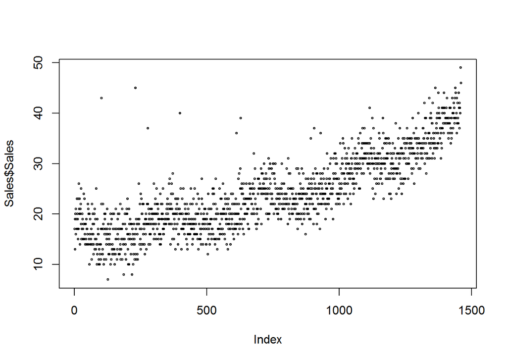

```r
plot(Sales$Sales, cex = 0.4)
```

From the above plot, we can observe a linear trend in the Sales data over time, which is not desired, as it implies time-dependency and non-stationarity, lets apply one level of differencing to Sales Data

2. Plot Sales Data with one level of differencing applied.

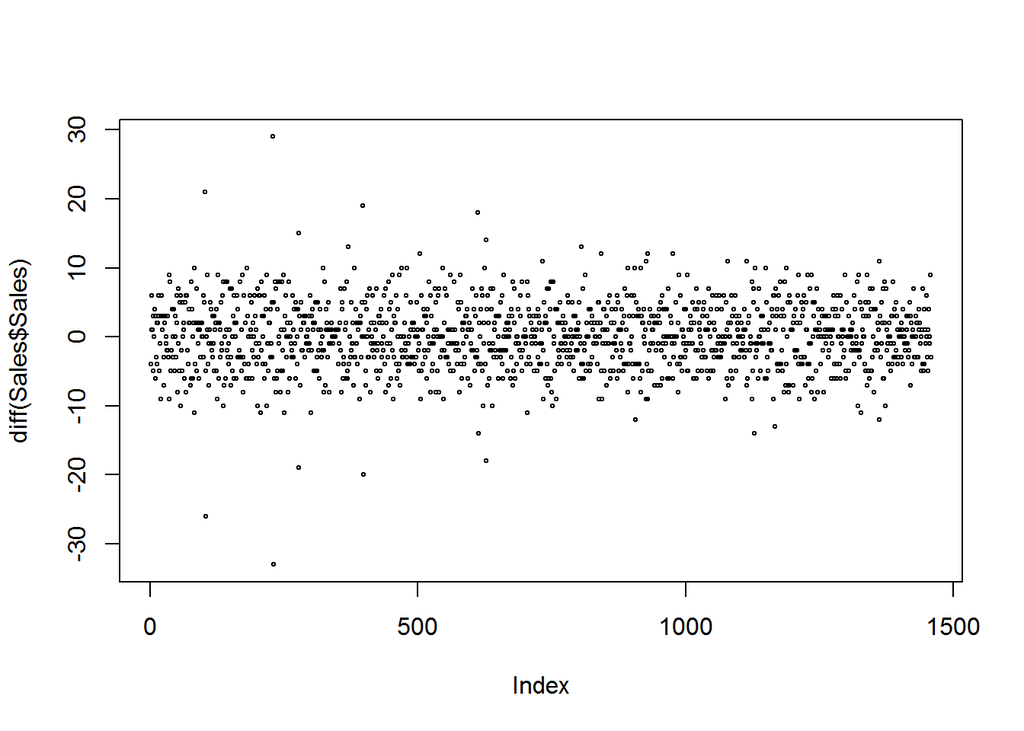

```r
plot(diff(Sales$Sales), cex = 0.4)
```

From, the above plot, we can infer that with one level of differencing the data, the linear trend observed initially vanished and the data has now turned stationary, for which ARIMA models can be applied.

The above differencing process is applied recursively until we obtain stationary data.

ADF Test is another option used to test the stationarity of data.

**Convert Data to Time Series Data**

```r
Sales$Date = substr(Sales$Date,1,10)
Sales$Date = as.Date(as.character(Sales$Date),format="%Y-%m-%d")

require(xts)
```

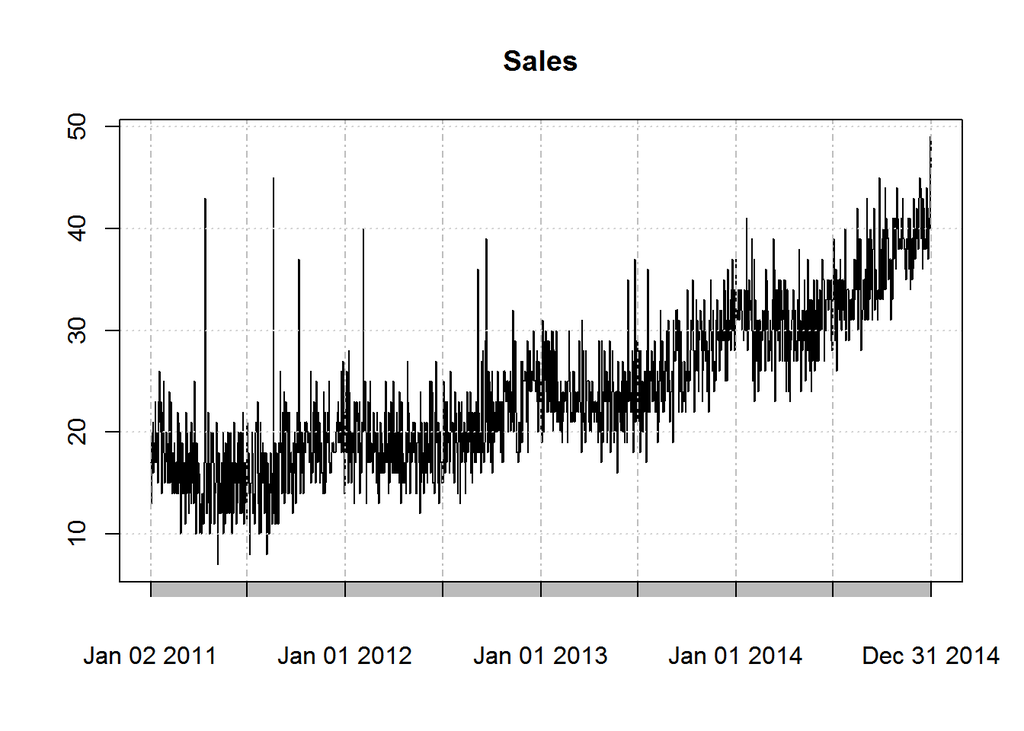

```r
Sales <- xts(Sales$Sales,Sales$Date)

# Plot Time-Series Data, to observe potential trend

plot(Sales)
```

The above time-series plot is in line with the assumptions made w.r.t data earlier.

```r
install.packages("forecast")
require(forecast)
require(tseries)
```

**Model Fitting using Auto Arima, it fits the best ARIMA model to univariate time series data**

Auto-ARIMA model emphasizes on minimization of AICs and MLE to find the best model

It selects the best model(chosses p and q) after finding qualifying value for d, differencing factor(I).

```r
arima_fit <- auto.arima(Sales)

# Summary of the Time-Series Model fitted above

summary(arima_fit)
```

```
## Series: Sales
## ARIMA(0,1,2) with drift
##
## Coefficients:
##           ma1      ma2   drift
##       -0.8983  -0.0457  0.0156
## s.e.   0.0265   0.0262  0.0053
##
## sigma^2 estimated as 12.86:  log likelihood=-3932.99
## AIC=7873.98   AICc=7874.01   BIC=7895.12
##
## Training set error measures:
##                       ME     RMSE      MAE      MPE     MAPE      MASE
## Training set 0.003581365 3.581021 2.695926 -2.92607 12.62549 0.7356192
##                      ACF1
## Training set -0.001289391
```

For the above Auto-AR(I)MA model, we have the differencing factor of 1, which implies that the time series Sales Data, turned stationary after apply one level of differencing to the data, as validated above.

The optimal values of parameters, (p,q) for an ARIMA model is usually found after analyzing ACF and PACF plots. But, auto-ARIMA model takes care of optmizing these parametes by building multiple models and choosing the best model.

ARIMA model, obtained above is ARIMA(0,1,2), which can be interpreted as follows: AR, p = 0, implies that there is no AR(Auto-Regressive) component model; d = 1, says that data needed one level of differencing to make it stationary; also q = 2, implies that it is MA(2), Moving Average model of second order or MA model with 2 lags.

In my learning and understanding, I see that there is no effect of previous/historic values in predicting the response variable for this model, as there is no auto-regressive component.

**Predictions for next 365 days**

```r
arima_forecast <- forecast(arima_fit, h = 365)

# Forecast of values for the following year(2015) with 95% and 80% Confidence Intervals as well.

arima_forecast
```

```
##      Point Forecast    Lo 80    Hi 80    Lo 95    Hi 95
## 1461       41.27872 36.68316 45.87428 34.25042 48.30703
## 1462       41.07371 36.45442 45.69299 34.00912 48.13830
## 1463       41.08934 36.46287 45.71580 34.01377 48.16490
## 1464       41.10496 36.47134 45.73859 34.01844 48.19149
## 1465       41.12059 36.47981 45.76137 34.02313 48.21806
## 1466       41.13622 36.48830 45.78415 34.02784 48.24461
## 1467       41.15185 36.49680 45.80691 34.03256 48.27114
## 1468       41.16748 36.50531 45.82966 34.03730 48.29766
## 1469       41.18311 36.51383 45.85240 34.04206 48.32417
## 1470       41.19874 36.52236 45.87513 34.04683 48.35065
## 1471       41.21437 36.53090 45.89784 34.05162 48.37712
## 1472       41.23000 36.53945 45.92055 34.05643 48.40358
## 1473       41.24563 36.54802 45.94325 34.06125 48.43001
## 1474       41.26126 36.55659 45.96593 34.06609 48.45644
```

[output cut: 351 more lines]

**Visualize the forecast of the model, for the following year(2015) to cross-validate that the model is working fine and is in line with the trends observed initially**

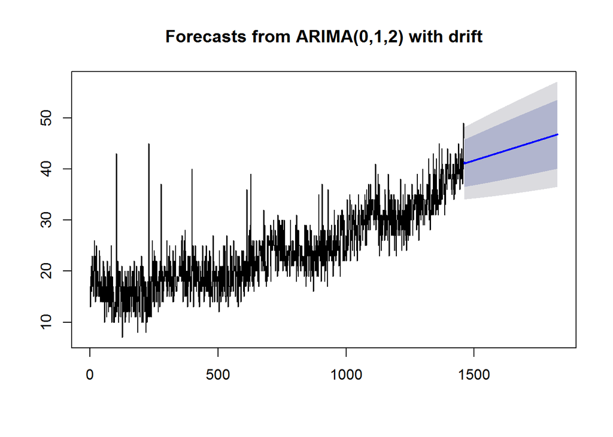

```r
plot(arima_forecast)
```

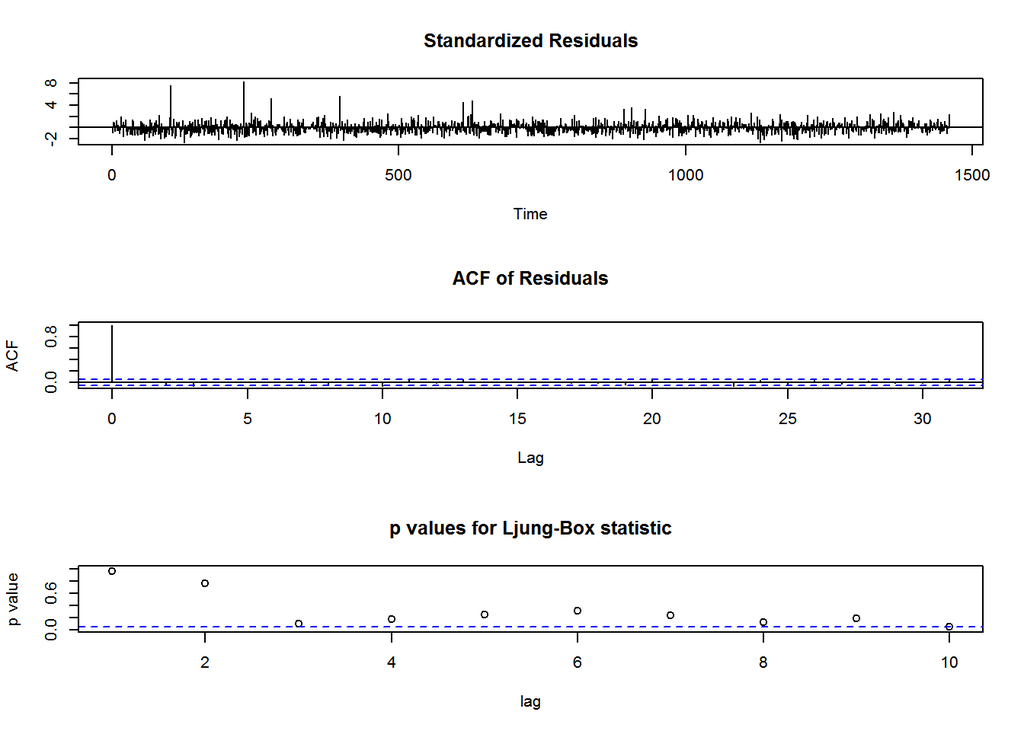

```r
# Residual Plots

tsdiag(arima_fit)
```

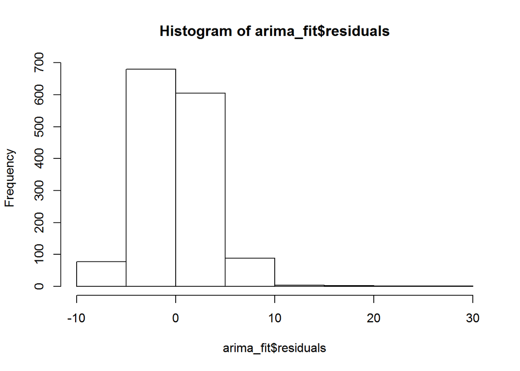

```r
# Histogram of Residuals

hist(arima_fit$residuals)
```

The histograms of residuals appear to be ~normal, however the right tail is a bit longer.

**Model Fit / WhiteNoise Test for Residuals**

**Test Used - Portmanteau test/Ljung-Box test**

```r
install.packages("TSA")
library(TSA)
```

```
## locfit 1.5-9.1    2013-03-22
##
##
##
##
```

```r
LB.test(arima_fit)
```

```
##
##  Box-Ljung test
##
## data:  residuals from  arima_fit
## X-squared = 23.1, df = 10, p-value = 0.01038
```